# IE 582 Statistical Learning for Data Mining

##### Homework 1

##### Fatih Mehmet Yılmaz - 2024702054

- With the rise of high-frequency communication systems like 5G, designing effective antennas is really important. These antennas need to perform well to send and receive signals in specific frequency ranges. However, figuring out how well an antenna works, especially **measuring S11 (which shows how much signal is reflected), can be very complex and requires a lot of computing power.**
- Traditional electromagnetic (EM) simulations are very accurate, but they need a lot of computing power and time, especially when testing different shapes and materials. This makes **it difficult to use trial and error to find the right antenna design that meets user needs.**
- The designer wants to find the S11 (return loss) values at different frequencies. For this homework, the designs are simulated in the frequency range of 23-33 GHz using Ansys HFSS (High Frequency Structural Simulator). The results include complex S11 values (real and imaginary parts) collected at **201 frequency points** to thoroughly assess the antenna’s performance.
- Since simulations take a lot of time and computing power, finding the best antenna design can be challenging. To tackle this, machine learning methods are being used more often to understand the relationship between the input (geometry) and the output (real and imaginary parts of S11 values). Techniques like **Principal Component Analysis (PCA)** and **supervised learning methods**, such as linear regression, are useful for analyzing and predicting data in antenna design.

This assignment uses simulated antenna design data to see how these methods can help simplify and capture complex relationships in the S-parameter dataset. **The goal is to better understand how design parameters relate to the S11 values.**

### 1. Introduction

```python
# Import necessary libraries
import pandas as pd
import numpy as np
import matplotlib.pyplot as plt
import seaborn as sns
from sklearn.preprocessing import StandardScaler
from sklearn.decomposition import PCA
from sklearn.linear_model import LinearRegression
from sklearn.metrics import mean_squared_error, r2_score
from sklearn.model_selection import train_test_split
from sklearn.decomposition import KernelPCA

import warnings
warnings.filterwarnings("ignore")
```

```python
# Load the design parameter data
input_data = pd.read_csv('hw1_input.csv')

# Load the real and imaginary parts of S11
real_data = pd.read_csv('hw1_real.csv')
imag_data = pd.read_csv('hw1_img.csv')

# Calculate the magnitude of S11
magnitude = np.sqrt(real_data**2 + imag_data**2)
```

```python
# First simple check of the data

print("Input Data Shape:", input_data.shape)
print("Real Part of S11 Shape:", real_data.shape)
print("Imaginary Part of S11 Shape:", imag_data.shape)
print("\nInput Data Info:")
print(input_data.info())
```

```
Input Data Shape: (385, 11)
Real Part of S11 Shape: (385, 201)
Imaginary Part of S11 Shape: (385, 201)

Input Data Info:
<class 'pandas.core.frame.DataFrame'>
RangeIndex: 385 entries, 0 to 384
Data columns (total 11 columns):
 #   Column                                      Non-Null Count  Dtype
---  ------                                      --------------  -----
 0   length of patch                             385 non-null    float64
 1   width of patch                              385 non-null    float64
 2   height of patch                             385 non-null    float64
 3   height of substrate                         385 non-null    float64
 4   height of solder resist layer               385 non-null    float64
 5   radius of the probe                         385 non-null    float64
 6   c_pad                                       385 non-null    float64
 7   c_antipad                                   385 non-null    float64
 8   c_probe                                     385 non-null    float64
 9   dielectric constant of substrate            385 non-null    float64
 10  dielectric constant of solder resist layer  385 non-null    float64
dtypes: float64(11)
memory usage: 33.2 KB
None
```

### 2. Dimensionality Reduction with PCA

###### - Check the magnitude to be had comparing to the graph given in the HW statement and also point the lowest magnitude of each design.

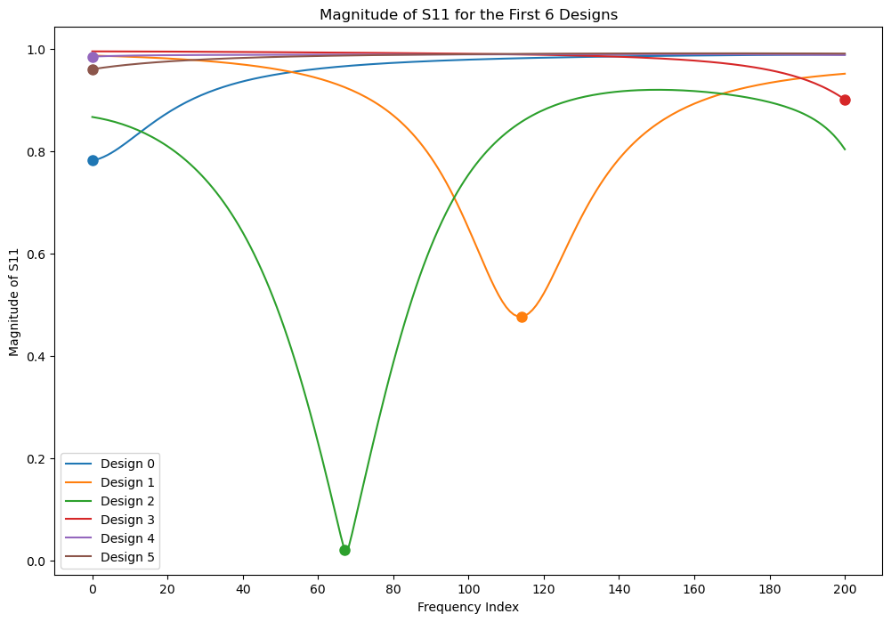

```python
plt.figure(figsize=(12, 8))

for i in range(6):
    # Plot the data for each design and get the line color
    line, = plt.plot(magnitude.iloc[i], label=f'Design {i}')
    line_color = line.get_color()  # Capture the color of the line

    # Find the index of the minimum value and plot a circle marker at that point with the same color
    min_index = magnitude.iloc[i].idxmin()
    min_value = magnitude.iloc[i].min()
    plt.plot(min_index, min_value, 'o', color=line_color, markersize=8)  # Use circle marker at min point

plt.xlabel('Frequency Index')
plt.ylabel('Magnitude of S11')
plt.title('Magnitude of S11 for the First 6 Designs')
plt.legend()
plt.grid(False)
plt.xticks(ticks=np.arange(0, 201, 20), labels=np.arange(0, 201, 20))
plt.show()
```

**- This graph ensured that we constructed the magnitude correctly.**

**SELECT THE CORRECT NUMBER OF PCA COMPONENTS**

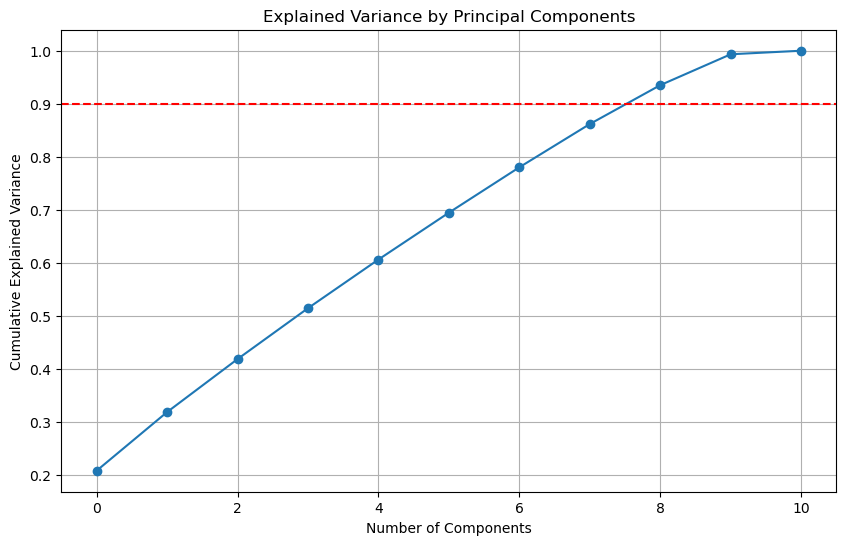

```python
# Standardize Input Data since pca is sensitive to the scale of the features.
scaler = StandardScaler()
input_data_scaled = scaler.fit_transform(input_data)

# PCA on input design parameters to find optimal component count
pca = PCA()
input_pca = pca.fit_transform(input_data_scaled)
explained_variance = pca.explained_variance_ratio_

# Plot the explained variance ratio for design parameters
plt.figure(figsize=(10, 6))
plt.plot(np.cumsum(explained_variance), marker='o')
plt.xlabel('Number of Components')
plt.ylabel('Cumulative Explained Variance')
plt.title('Explained Variance by Principal Components')
plt.grid(True)
plt.axhline(y=0.90, color='r', linestyle='--')  # 95% variance threshold
plt.show()
```

```python
n_components_input = np.argmax(np.cumsum(explained_variance) >= 0.90)
print(f"Optimal number of components selected: {n_components_input}")

# Apply PCA with chosen number of components
pca_input = PCA(n_components=n_components_input)
principal_components_input = pca_input.fit_transform(input_data_scaled)
```

```
Optimal number of components selected: 8
```

**In this part, the number of principal components is selected based on the total explained variance.**

```python
# Create a DataFrame to store the loadings for the selected number of components
principal_components_df = pd.DataFrame(data=pca_input.components_, columns=input_data.columns)

# Identify the most important factor for each component
important_factors = {}

for i in range(8):  # For the first 8 components
    # Find the feature with the maximum absolute loading for this component
    component_loadings = principal_components_df.iloc[i]
    most_important_feature = component_loadings.abs().idxmax()  # Get feature with highest absolute loading
    loading_value = component_loadings[most_important_feature]

    important_factors[f'PC{i+1}'] = (most_important_feature, loading_value)

# Display the most important factors
print("\nMost Important Factor for Each Principal Component:")
for component, (feature, loading) in important_factors.items():
    print(f"{component}: {feature} (Loading: {loading:.4f})")
```

```
Most Important Factor for Each Principal Component:
PC1: width of patch (Loading: 0.6242)
PC2: c_probe (Loading: -0.5648)
PC3: height of patch (Loading: 0.6205)
PC4: height of solder resist layer (Loading: 0.5107)
PC5: c_pad (Loading: -0.5801)
PC6: dielectric constant of solder resist layer (Loading: 0.5917)
PC7: height of solder resist layer (Loading: 0.6472)
PC8: radius of the probe (Loading: -0.4915)
```

##### 1. Reducing Complexity with PCA:

PCA can **simplify the design space** by identifying the key parameters that most influence the S11 response of the antenna. By focusing on the principal components, you can **reduce the number of variables (from 11 to 8) while retaining most of the important information**. This makes it easier to analyze and optimize antenna designs without getting overwhelmed by the complexity of the full parameter space.

##### 3. Insights from PCA:

Most Important Factor for Each Principal Component:

1. PC1: width of patch (Loading: 0.6242)
2. PC2: c_probe (Loading: -0.5648)
3. PC3: height of patch (Loading: 0.6205)
4. PC4: height of solder resist layer (Loading: 0.5107)
5. PC5: c_pad (Loading: -0.5801)
6. PC6: dielectric constant of solder resist layer (Loading: 0.5917)
7. PC7: height of solder resist layer (Loading: 0.6472)
8. PC8: radius of the probe (Loading: -0.4915)

### 3. Regression Modeling for S11

```
Real Part - MSE: 0.1860, R^2: 0.1488
Imaginary Part - MSE: 0.1303, R^2: 0.0901
```

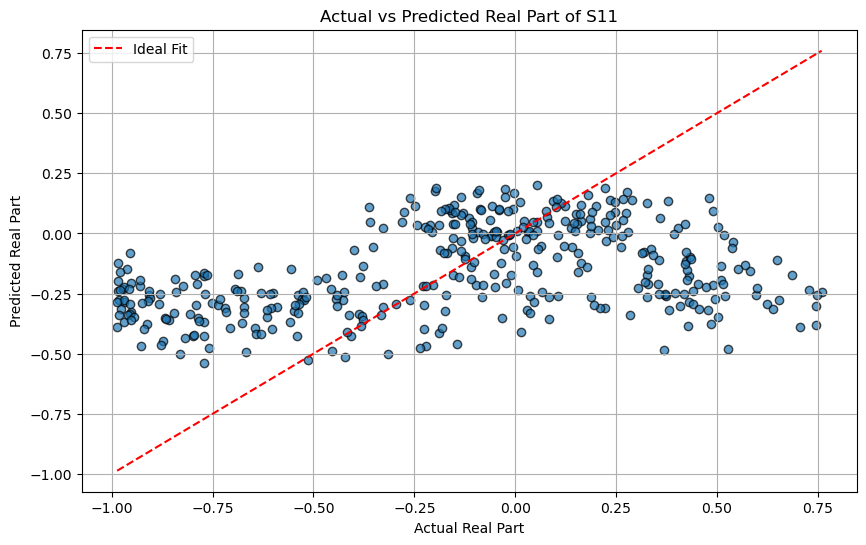

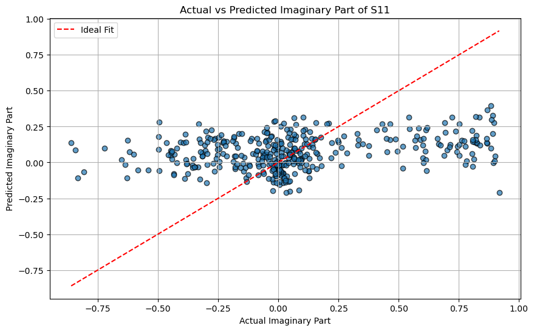

```python
# Select Frequency Points with Minimum S11 Magnitude for Each Design
selected_frequencies = magnitude.idxmin(axis=1).to_numpy().astype(int)

# Extract Real and Imaginary S11 at Selected Frequencies
y_real = real_data.to_numpy()[np.arange(len(real_data)), selected_frequencies]
y_imag = imag_data.to_numpy()[np.arange(len(imag_data)), selected_frequencies]

# Linear Regression with PCA-reduced data
model_real = LinearRegression()
model_imag = LinearRegression()
model_real.fit(principal_components_input, y_real)
model_imag.fit(principal_components_input, y_imag)

y_real_pred = model_real.predict(principal_components_input)
y_imag_pred = model_imag.predict(principal_components_input)

# Model Evaluation
mse_real = mean_squared_error(y_real, y_real_pred)
r2_real = r2_score(y_real, y_real_pred)
mse_imag = mean_squared_error(y_imag, y_imag_pred)
r2_imag = r2_score(y_imag, y_imag_pred)

print(f"Real Part - MSE: {mse_real:.4f}, R^2: {r2_real:.4f}")
print(f"Imaginary Part - MSE: {mse_imag:.4f}, R^2: {r2_imag:.4f}")

# Visualize Actual vs Predicted for Real Part
plt.figure(figsize=(10, 6))
plt.scatter(y_real, y_real_pred, edgecolor='k', alpha=0.7)
plt.plot([y_real.min(), y_real.max()], [y_real.min(), y_real.max()], 'r--', label="Ideal Fit")
plt.xlabel('Actual Real Part')
plt.ylabel('Predicted Real Part')
plt.title('Actual vs Predicted Real Part of S11')
plt.legend()
plt.grid(True)
plt.show()

# Visualize Actual vs Predicted for Imaginary Part
plt.figure(figsize=(10, 6))
plt.scatter(y_imag, y_imag_pred, edgecolor='k', alpha=0.7)
plt.plot([y_imag.min(), y_imag.max()], [y_imag.min(), y_imag.max()], 'r--', label="Ideal Fit")
plt.xlabel('Actual Imaginary Part')
plt.ylabel('Predicted Imaginary Part')
plt.title('Actual vs Predicted Imaginary Part of S11')
plt.legend()
plt.grid(True)
plt.show()
```

```
Kernel: rbf, Gamma: 0.01
Real Part - MSE: 0.1860, R^2 Score: 0.1488
Imaginary Part - MSE: 0.1303, R^2 Score: 0.0903

Kernel: rbf, Gamma: 0.1
Real Part - MSE: 0.1873, R^2 Score: 0.1430
Imaginary Part - MSE: 0.1291, R^2 Score: 0.0986

Kernel: rbf, Gamma: 1
Real Part - MSE: 0.2044, R^2 Score: 0.0648
Imaginary Part - MSE: 0.1336, R^2 Score: 0.0675

Kernel: rbf, Gamma: 10
Real Part - MSE: 0.2089, R^2 Score: 0.0438
Imaginary Part - MSE: 0.1354, R^2 Score: 0.0545

Kernel: poly, Gamma: N/A
Real Part - MSE: 0.1858, R^2 Score: 0.1498
Imaginary Part - MSE: 0.1306, R^2 Score: 0.0883

Best Kernel PCA Configuration:
Kernel: rbf, Gamma: 0.01
Best Real Part - MSE: 0.1860, R^2 Score: 0.1488
Best Imaginary Part - MSE: 0.1303, R^2 Score: 0.0903
```

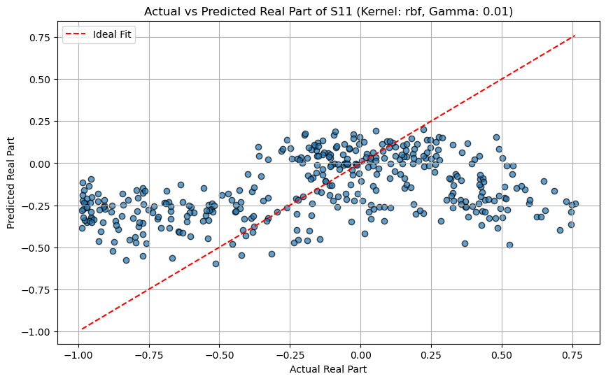

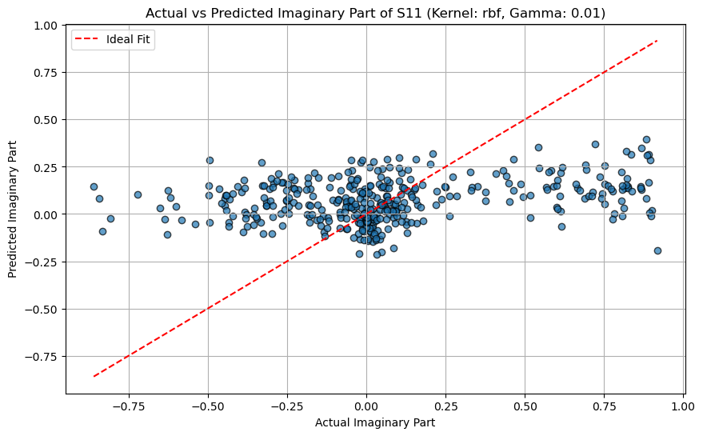

```python
# Optional: Use KernelPCA for Nonlinear Dimensionality Reduction
kernel_pca = KernelPCA(n_components=8, kernel='rbf', gamma=0.1)
principal_components_input_kpca = kernel_pca.fit_transform(input_data_scaled)

# Define parameter values to test in Kernel PCA
n_components = 8  # Number of components to keep
gamma_values = [0.01, 0.1, 1, 10]  # Different gamma values to try for the RBF kernel
kernels = ['rbf', 'poly']  # Kernels to test: RBF and Polynomial

# Prepare variables to store the best results
best_mse_real, best_mse_imag = float('inf'), float('inf')
best_r2_real, best_r2_imag = None, None
best_params = {}

# Loop over each kernel and gamma value
for kernel in kernels:
    for gamma in gamma_values if kernel == 'rbf' else [None]:  # gamma is relevant only for 'rbf'

        # Initialize and fit Kernel PCA with current parameters
        if gamma:
            kernel_pca = KernelPCA(n_components=n_components, kernel=kernel, gamma=gamma)
        else:
            kernel_pca = KernelPCA(n_components=n_components, kernel=kernel)

        principal_components_input_kpca = kernel_pca.fit_transform(input_data_scaled)

        # Linear Regression on the Kernel PCA-reduced data
        model_real = LinearRegression()
        model_imag = LinearRegression()
        model_real.fit(principal_components_input_kpca, y_real)
        model_imag.fit(principal_components_input_kpca, y_imag)

        # Predict the real and imaginary components of S11 at selected frequency points
        y_real_pred = model_real.predict(principal_components_input_kpca)
        y_imag_pred = model_imag.predict(principal_components_input_kpca)

        # Evaluate the models using Mean Squared Error and R^2 score
        mse_real = mean_squared_error(y_real, y_real_pred)
        r2_real = r2_score(y_real, y_real_pred)
        mse_imag = mean_squared_error(y_imag, y_imag_pred)
        r2_imag = r2_score(y_imag, y_imag_pred)

        # Output results for the current configuration
        print(f"\nKernel: {kernel}, Gamma: {gamma if gamma else 'N/A'}")
        print(f"Real Part - MSE: {mse_real:.4f}, R^2 Score: {r2_real:.4f}")
        print(f"Imaginary Part - MSE: {mse_imag:.4f}, R^2 Score: {r2_imag:.4f}")

        # Check if this is the best model so far and save if it is
        if mse_real < best_mse_real and mse_imag < best_mse_imag:
            best_mse_real, best_mse_imag = mse_real, mse_imag
            best_r2_real, best_r2_imag = r2_real, r2_imag
            best_params = {'kernel': kernel, 'gamma': gamma}

# Display best results
print("\nBest Kernel PCA Configuration:")
print(f"Kernel: {best_params['kernel']}, Gamma: {best_params['gamma']}")
print(f"Best Real Part - MSE: {best_mse_real:.4f}, R^2 Score: {best_r2_real:.4f}")
print(f"Best Imaginary Part - MSE: {best_mse_imag:.4f}, R^2 Score: {best_r2_imag:.4f}")

# Plot actual vs predicted for the best configuration
# Assuming best configuration is stored in `principal_components_input_kpca`
# Visualize Actual vs Predicted for Real Part
plt.figure(figsize=(10, 6))
plt.scatter(y_real, y_real_pred, edgecolor='k', alpha=0.7)
plt.plot([y_real.min(), y_real.max()], [y_real.min(), y_real.max()], 'r--', label="Ideal Fit")
plt.xlabel('Actual Real Part')
plt.ylabel('Predicted Real Part')
plt.title(f'Actual vs Predicted Real Part of S11 (Kernel: {best_params["kernel"]}, Gamma: {best_params["gamma"]})')
plt.legend()
plt.grid(True)
plt.show()

# Visualize Actual vs Predicted for Imaginary Part
plt.figure(figsize=(10, 6))
plt.scatter(y_imag, y_imag_pred, edgecolor='k', alpha=0.7)
plt.plot([y_imag.min(), y_imag.max()], [y_imag.min(), y_imag.max()], 'r--', label="Ideal Fit")
plt.xlabel('Actual Imaginary Part')
plt.ylabel('Predicted Imaginary Part')
plt.title(f'Actual vs Predicted Imaginary Part of S11 (Kernel: {best_params["kernel"]}, Gamma: {best_params["gamma"]})')
plt.legend()
plt.grid(True)
plt.show()
```

### 4. Model Performance and Interpretability

**1. Instead, can we simplify the regression task by focusing on predicting S11 at a few key frequency points?**

**To simplify the regression task, we selected a few key frequency points where the S11 parameters exhibit critical behavior, such as resonance points where S11 is closest to zero**. This allows us to avoid predicting all 201 frequency points and instead focus on points with significant performance implications for antenna design.

By reducing the number of target frequency points, we make the task more computationally manageable. This approach is effective because:

- It captures the most relevant aspects of antenna performance (reflection and resonance).
- It avoids the complexity and computational load of predicting S11 across a broad frequency range, focusing on frequencies that are most critical for signal transmission and reception.

**2. How effective are linear regression models in predicting the real and imaginary components of S11 at these selected frequency points, based on the geometric parameters of the antenna design?**

After selecting the critical frequencies, we applied linear regression models to predict the real and imaginary parts of S11 based on the geometric design parameters of the antenna. Here is what we observed:

**3.What patterns emerge when linear regression is applied to individual frequency points, and do these patterns suggest any broader trends in the design space?**

When linear regression was applied to individual frequency points, the following patterns and trends emerged:

1. Nonlinear Relationships: The dispersion around the ideal fit line in the actual vs. predicted plots suggested that the relationship between design parameters and S11 components is not entirely linear. This indicates that antenna performance may be influenced by complex interactions between design parameters.
2. Sensitivity to Design Changes: Certain design parameters appeared to have a stronger impact on specific frequency points, particularly those associated with resonance. This suggests that the antenna’s performance is highly sensitive to changes in certain geometric parameters, making these features particularly important for design optimization.
3. Broader Design Trends: Although the linear model did not capture all nuances, it highlighted some general trends, like which parameters were more influential in determining resonance behaviors. This insight is valuable for antenna design, as it can guide further investigations with more advanced models.

##### Model Performance and Interpretability

The combination of PCA and linear regression models offers some benefits for simplifying and predicting antenna performance, but with limitations:

**PCA for Dimensionality Reduction:** PCA effectively reduced the design parameter space, allowing us to focus on a smaller set of transformed features (principal components) while retaining most of the variance. This helped streamline the regression task by reducing the number of input variables.

**Linear Regression for Predicting S11:** Linear regression was straightforward to implement and interpret, providing an initial understanding of the relationships between design parameters and S11 components. However, its simplicity was also a drawback, as it struggled with the nonlinearity in the data.

In summary, PCA and linear regression models provide a good starting point for simplification but may not fully capture the complexities of antenna performance due to their linear assumptions.

**PCA Limitations:** PCA assumes that the most informative directions are those with the highest variance, which might not always align with the aspects of the design space that affect S11 the most. Additionally, PCA is a linear transformation and may fail to capture non-linear relationships.

**Linear Regression Limitations:** Linear regression assumes a linear relationship between features and the target, which is likely too simplistic for modeling complex electromagnetic behavior. The data suggests that there are nonlinear interactions in the design space that linear regression cannot capture effectively.

**Potential Improvements:**

- Nonlinear Dimensionality Reduction: Techniques like Kernel PCA(in our case, I cannot improve the regression with only kernel pca) could capture non-linear patterns in the data.
- Advanced Regression Models: Using models capable of capturing non-linear relationships, such as Support Vector Regression (SVR), Gradient Boosting Machines (GBM), or Neural Networks, could provide more accurate predictions.
- Feature Engineering: Adding interaction terms or creating custom features based on known antenna design principles may enhance model performance by making important relationships more explicit.

**In conclusion, while PCA and linear regression offer a foundational approach, more advanced models and methods are likely needed to accurately model the nonlinear and complex behavior of antenna S11 performance.**

### 5. Summary

###### Methodologies

**1. Data Preprocessing:**

The design parameters were standardized before applying PCA. Standardization was crucial because PCA is sensitive to the scale of the input data. By centering the data to have a mean of 0 and a standard deviation of 1, we ensured that each feature contributed equally to the principal components.

**2. Dimensionality Reduction with PCA:**

We applied Principal Component Analysis (PCA) to the standardized design parameters to reduce the dimensionality of the data.

This was necessary because high-dimensional data can be noisy and computationally intensive to model.

We selected the number of components by analyzing the cumulative explained variance plot, targeting components that collectively explain a significant portion of the variance while simplifying the feature set. In this case, using 8 components provided a reasonable balance, retaining most of the relevant variance.

**3. Kernel PCA for Nonlinear Patterns:**

Given that the relationships between design parameters and S11 values are likely nonlinear, we experimented with Kernel PCA (KPCA), specifically with an RBF kernel.

Kernel PCA aims to capture nonlinear patterns that standard PCA might miss by transforming the data into a higher-dimensional space where linear separability is more achievable.

**4. Linear Regression Models:**

After dimensionality reduction, linear regression was performed on the transformed principal components to predict the real and imaginary parts of the S11 parameter at key frequency points. Linear regression was chosen for its simplicity and interpretability, serving as a baseline to evaluate how well linear relationships could approximate the data.

**5. Model Evaluation:**

The model’s performance was assessed using Mean Squared Error (MSE) and ( R^2 ) scores for both the real and imaginary parts of S11. MSE indicates the average prediction error, while ( R^2 ) measures the proportion of variance explained by the model. Low ( R^2 ) values suggest that the linear model may struggle to capture the complexity of the data.

###### Findings

1. PCA Results

The results from applying PCA followed by linear regression show moderate Mean Squared Error (MSE) scores but relatively low (R^2)values:

Real Part: MSE: 0.1860 (R^2): 0.1488

Imaginary Part: MSE: 0.1303 (R^2): 0.0901

These low (R^2) scores indicate that while the model can predict some aspects of the S11 parameter’s behavior, a significant portion of the variance remains unexplained. This suggests that the relationships between the design parameters and S11 are likely more complex than what a linear model can capture.

2. Kernel PCA Results

When using Kernel PCA with an RBF kernel (gamma set to 0.01), the results did not show substantial improvements over standard PCA. The MSE and ( R^2 ) values remained similar, indicating that while Kernel PCA introduced some nonlinearity, it may not have fully captured the complexity needed for accurate predictions.

**This finding implies that although nonlinearity exists in the data, it may require more sophisticated modeling techniques or further tuning of parameters to effectively capture these relationships.**

###### Patterns Observed:

The actual vs. predicted plots showed that the linear regression model, even with dimensionality reduction, struggles with dispersion around the ideal fit line. This dispersion implies that the relationship between the input parameters and S11 is likely nonlinear.

###### Conclusions and Real-World Implications

**Linear Models’ Limitations:**

Linear regression is limited in capturing complex, nonlinear relationships between design parameters and antenna performance metrics like S11. This aligns with real-world observations in antenna design, where electromagnetic behaviors are often highly nonlinear due to interactions between geometry, materials, and frequency.

**Dimensionality Reduction is Useful but Not Sufficient:**

PCA and Kernel PCA helped simplify the design space, making the regression task more manageable. However, dimensionality reduction alone cannot account for nonlinearity in relationships. Real-world antenna design likely requires nonlinear models to achieve accurate predictions of parameters like S11 across varying frequencies.

###### Challenges and Solutions

**1. Challenge: Capturing Nonlinearity**

- Problem: The primary challenge was capturing the complex, nonlinear relationship between design parameters and S11 values. Linear regression inherently assumes a straight-line relationship, which doesn’t fully represent the behaviors in electromagnetic simulations.
- Solution: We introduced Kernel PCA to capture some nonlinear patterns, but the results showed only marginal improvement. To overcome this challenge more effectively, experimenting with more sophisticated nonlinear regression models (like Support Vector Regression, Gradient Boosting, or Neural Networks) would likely yield better results.

**2. Challenge: Dimensionality Reduction Trade-offs**

- Problem: Balancing the number of components in PCA or Kernel PCA was challenging. Reducing dimensions too aggressively risks losing critical information, while keeping too many components makes the model more complex and computationally intensive.
- Solution: We used explained variance as a guide to select the number of components. However, this approach could be improved by testing more components or using domain knowledge to prioritize specific features tied to S11 behavior.

**3. Challenge: Parameter Tuning in Kernel PCA**

- Problem: Selecting optimal parameters (such as gamma for the RBF kernel in Kernel PCA) was challenging, as it required trial and error to find a setting that effectively captured the data structure.
- Solution: We tested multiple values for gamma and other kernels. To improve this, a more systematic parameter search (e.g., grid search or random search) could be applied to optimize Kernel PCA settings and potentially improve the model’s ability to capture nonlinearity.

###### Future Directions

To improve the model further, the following steps could be beneficial:

**Experimenting with Nonlinear Models:** Try Support Vector Regression, Random Forest, or Neural Networks, as these models can capture complex interactions and nonlinear patterns that linear regression cannot.

**Feature Engineering:** Consider creating additional features, such as interaction terms or nonlinear transformations, that could help linear models capture more complex relationships.

**Hyperparameter Tuning with Cross-Validation:** For Kernel PCA and other models, using grid search or cross-validation to tune parameters could improve model performance and help identify the best settings more efficiently.

In conclusion, while PCA and linear regression provide a useful starting point for understanding antenna performance, the complexity of the data suggests that nonlinear modeling approaches and additional tuning would likely yield better predictive accuracy for real-world applications in antenna design.